# Intro to Backpropagation

### Types of Learning

- Supervised learning — the training set consists of inputs and the expected output
  - A dataset is often partitioned into a *training set* and a *testing set*. The testing set is used to assess the model's prediction accuracy
- Unsupervised learning — the training set only contains input and the learning model is expected to find structure in these inputs
- Reinforcement learning — the learning model aims to maximise a reward signal

## Curve Fitting

### Ockham's Razor

Asserts that "the most likely hypothesis is the simplest one consistent with the data"

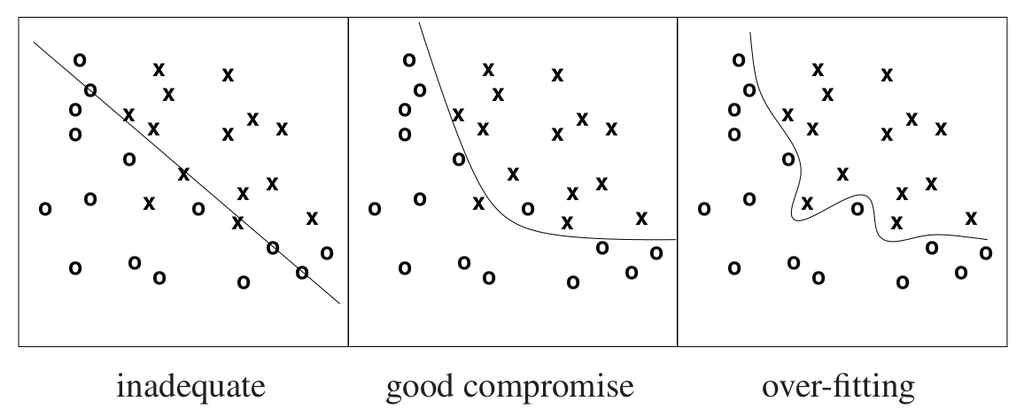

Overfitting is when the learning model is too fine-tuned to the noise rather than the true signal.

### Training

Learning is about adjusting weights to achieve a configuration that minimises the *error function*.

Example error function: $E=\frac{1}{2}\sum_{i} (z_i-t_i)^2$, where $z_i$ is a particular output prediction and $t_i$ is the expected value. Note the $\frac{1}{2}$ is chosen so that the coefficient is conveniently canceled when we differentiate the error function.

### Continuous Activation Functions

A requirement for backpropagation in multi-layer perceptrons is a differentiable activation function, since backpropagation uses gradient descent to adjust weights. Since the Heaviside step function's derivative has a value of $0$ everywhere, gradient descent can't make progress in updating the weights.

A good set of alternative functions to the step function are *sigmoid* functions.

- Logistic sigmoid: $g(s)=\frac{1}{1+e^{-s}}$
  - In stats, *logistic regression* is used to model the probability of a binary event (eg. alive/dead, cat/non-cat, etc.). Like all regression analyses, logistic regression is a form of predictive analysis
- Hyperbolic tan: $g(s)=tanh(s)=\frac{e^s-e^{-s}}{e^s+e^{-s}}=2(\frac{1}{1+e^{-2}}) - 1$
  - $tanh$ is just the logistic sigmoid function doubled and then shifted down 1 unit vertically

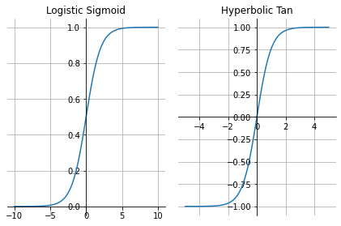

```python
import numpy as np
import matplotlib.pyplot as plt

fig = plt.figure()
x = np.linspace(-10, 10, 100)
y = 1 / (1 + np.exp(-x))

ax = fig.add_subplot(1, 2, 1)
ax.set_title('Logistic Sigmoid')
ax.plot(x, y)
ax.spines['left'].set_position('zero')
ax.spines['right'].set_color('none')
ax.spines['bottom'].set_position('zero')
ax.spines['top'].set_color('none')
ax.grid()

# remove the ticks from the top and right edges
ax.xaxis.set_ticks_position('bottom')
ax.yaxis.set_ticks_position('left')

x = np.linspace(-5, 5, 100)
y = np.tanh(x)

ax = fig.add_subplot(1, 2, 2)
ax.set_title('Hyperbolic Tan')
ax.plot(x, y)
ax.spines['left'].set_position('zero')
ax.spines['right'].set_color('none')
ax.spines['bottom'].set_position('zero')
ax.spines['top'].set_color('none')
ax.grid()

# remove the ticks from the top and right edges
ax.xaxis.set_ticks_position('bottom')
ax.yaxis.set_ticks_position('left')

plt.tight_layout()
```

### Preprocessing

- Input values often need to be normalised to values between 0 and 1. Eg. if one input $x_i$ is far larger than another input $x_j$, then $x_i$ would be have disproportionately more influence in backpropagation than $x_j$

### Gradient Descent:

## Backpropagation

- This is just a simple implementation of chain rule

Gradient descent is the process of adjusting network parameters to minimise the loss function, using the derivatives calculated in backpropagation.

The *loss function* computes the error for a single traning example.

- Mean squared error: $E(z, t)=\frac{1}{2}(z-t)^2$, where $z$ is the predicted value and $t$ is the target/expected value
- Cross-entropy: $E(z, t)=-(t\log(z)+(1-t)\log(1-z))$

The *cost function* computes the average of the loss function values across the entire training set: $\frac{1}{m}\sum_{i=1}^m E(z^{(i)}, t^{(i)})$, where $m$ is the total number of training examples and $z^{(i)}$ and $t^{(i)}$ are the prediction and target value for the $i^{\text{th}}$ training sample respectively.

### Resources

- Backpropagation:
  - https://towardsdatascience.com/the-heart-of-artificial-neural-networks-26627e8c03ba
- Gradient descent:
  - https://towardsdatascience.com/epoch-vs-iterations-vs-batch-size-4dfb9c7ce9c9

```python
from IPython.display import HTML

HTML('''<script>
code_show=true;
function code_toggle() {
 if (code_show){
 $('div.input').hide();
 } else {
 $('div.input').show();
 }
 code_show = !code_show
}
$( document ).ready(code_toggle);
</script>
<form action="javascript:code_toggle()"><input type="submit" value="Click to show/hide raw code"></form>''')
```